# GLM Binary - Spiders

[figure not shown]

As an example of simple logistic regression, Suzuki et al. (2006) measured sand grain size on 28 beaches in Japan and observed the presence or absence of the burrowing wolf spider *Lycosa ishikariana* on each beach. Sand grain size is the predictor variable and spider presence or absence is the response variable. If there is a relationship between the two variables, it would be sand grain size affecting spider occurrence, not the presence of spiders affecting the sand.

One goal of this study would be to determine whether there was a relationship between sand grain size and the presence or absence of the species, in hopes of understanding more about the biology of the spiders. Because this species is endangered, another goal would be to find an equation that would predict the probability of a wolf spider population surviving on a beach with a particular sand grain size, to help determine which beaches to reintroduce the spider to.

```r
library(readr)
spiders <- read_csv("practice_examples/spiders.csv")
```

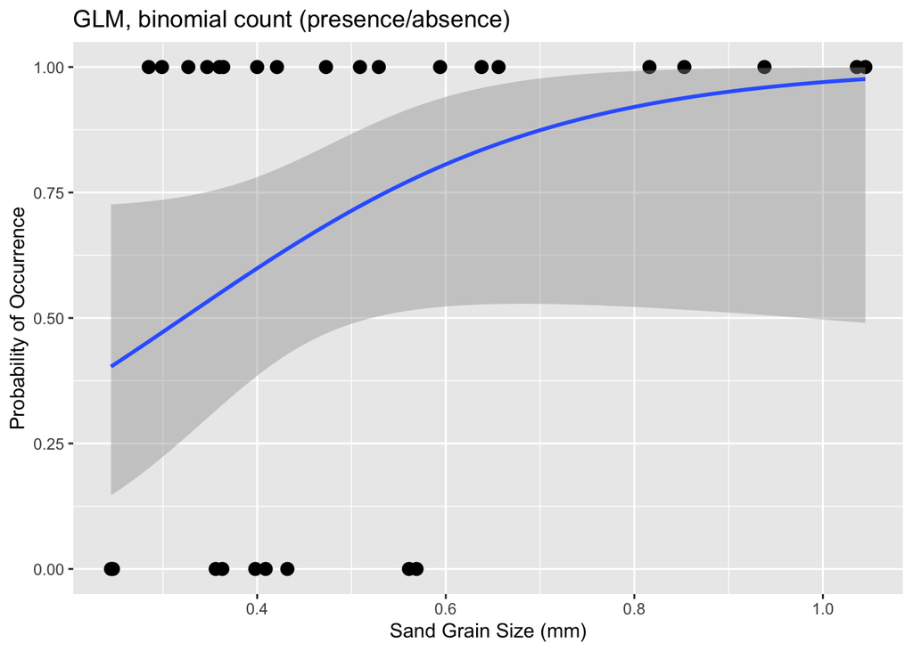

```r
ggplot(spiders, aes(grainsize, status_binary)) +
  geom_point(size=3) +
  geom_smooth(method="glm", method.args=list(family="binomial"(link="logit"))) +
  labs(title="GLM, binomial count (presence/absence)") +
  ylab ("Probability of Occurrence") +
  xlab ("Sand Grain Size (mm)")
```

```r
model_spider <- glm(status_binary ~ grainsize, data=spiders, family=binomial)
model_spider
```

```
##
## Call:  glm(formula = status_binary ~ grainsize, family = binomial, data = spiders)
##
## Coefficients:
## (Intercept)    grainsize
##       -1.65         5.12
##
## Degrees of Freedom: 27 Total (i.e. Null);  26 Residual
## Null Deviance:       35
## Residual Deviance: 31    AIC: 35
```

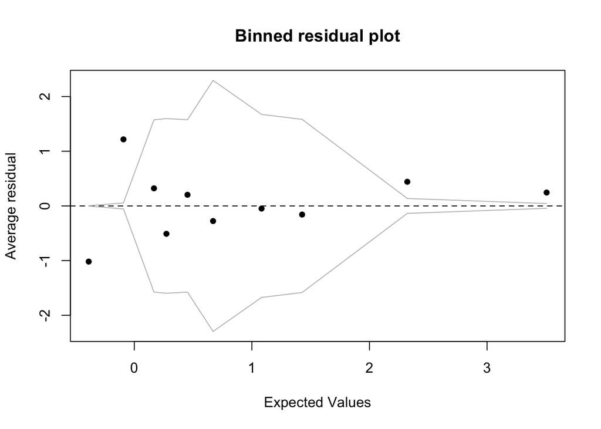

```r
library(arm)
x <- predict(model_spider)
y <- resid(model_spider)
binnedplot(x, y)
```

The grey lines in the plot indicate ±2 standard errors, within which approximately 95% of the binned residuals are expected to fall.

```r
coef(model_spider)
```

```
## (Intercept)   grainsize
##        -1.6         5.1
```

```r
confint(model_spider)
```

```
##             2.5 % 97.5 %
## (Intercept) -4.76   0.73
## grainsize    0.34  12.52
```

```r
summary(model_spider)
```

```
##
## Call:
## glm(formula = status_binary ~ grainsize, family = binomial, data = spiders)
##
## Deviance Residuals:
##    Min      1Q  Median      3Q     Max
## -1.741  -1.078   0.484   0.981   1.258
##
## Coefficients:
##             Estimate Std. Error z value Pr(>|z|)
## (Intercept)    -1.65       1.35   -1.22    0.224
## grainsize       5.12       3.01    1.70    0.088 .
## ---
## Signif. codes:  0 '***' 0.001 '**' 0.01 '*' 0.05 '.' 0.1 ' ' 1
##
## (Dispersion parameter for binomial family taken to be 1)
##
##     Null deviance: 35.165  on 27  degrees of freedom
## Residual deviance: 30.632  on 26  degrees of freedom
## AIC: 34.63
##
## Number of Fisher Scoring iterations: 5
```